[figure not shown]

# 1. Introduction

## Introduction 1

### Guidebook for Webpage Project

#### Overview

January 13–31 2020  
Smithsonian Tropical Research Institute  
Panama

Welcome to NEO-BESS Panama 2020. As part of the course this year, you will each create a stand-alone HTML webpage using open source platforms. Your page will contain a record of the science you conducted during the course, including interactive tables and figures. The goal is for each of you to document your work and package it all in an HTML page that will be published on-line.

First off, my name is Jarrod Scott. I am a postdoc at STRI and one of the course instructors. I will be the person in charge of the web project portion of the course. What that means first and foremost is that when you want to yell at someone, I am your guy. I am not a web developer or a coder, I am a biologist like you. I am always looking for better ways to organize, analyze, and communicate my science. I recently started using these tools to make web-based science products and my goal is to get you excited about these tools and help you find ways to use them in your own work.

With a little practice the tools you learn in this course can be used to create a range of document types, from a single .html or .pdf file, to multi-page web sites, to books, **presentations**, and even your **thesis or dissertation**.

Some of you may have far more experience with these tools than I do. That’s great–you can help me and help your classmates. If you think something I say doesn’t make sense, please say something. I would rather do something the right way than be right about the way I am doing something.

This guidebook will serve as a resource for you as you create your webpage project. As we go through the course, this page will be continually updated with new tips and tricks, useful resources, project goals, etc. You will all have the opportunity to add stuff to this page so that other students in the course can benefit from what you learn. For now though we will keep it simple and just focus on some bare bones prep work. But please check back here periodically for updates. We will try to make it obvious when new material is added.

## Introduction 2

### Highlights

We will primarily use [R Markdown](https://rmarkdown.rstudio.com/) to write the webpage content and [R](https://www.r-project.org/) / [RStudio](https://rstudio.com/) to build the page. We appreciate that some of you may have no experience at all with these tools and that’s OK. Part of the reason we are doing this is that we want you to walk away from this course with tools that you can use moving forward in your graduate career and beyond. I promise that at times it will be frustrating but I also promise that it will be worth the effort.

It is worth noting that this guidebook was written using many of the tools you will use in your web project.

Please complete the following before arriving in Panama. See the subsequent document for more details.

1. Read this document. It is best to go in order, at least the first time.
2. Familiarize yourself with R Markdown. Go through [this material](https://rmarkdown.rstudio.com/lesson-1.html) from RStudio first and then look at *Yihui Xie’s* [book on R Markdown](https://bookdown.org/yihui/rmarkdown/). You can download this book as a pdf in case you want to read it on the plane.
3. Install R, RStudio, and required R packages. See the instructions in section **5. Installing Software**.
4. Look at this website for inspiration https://rmarkdown.rstudio.com/ especially the Gallery section.
5. In your favorite search engine query this search term `R Markdown Cheatsheet`. Download some of the pdfs. These are invaluable.

**A note** on the format and use of this site. This site was constructed using [flexdashboard](https://rmarkdown.rstudio.com/flexdashboard/). Each page typically has two or more panels and each panel in like its own page. So depending on your screen size, you may need to scroll individual panels to see the full content.

# 2. Rationale

OK lets justify some of what we will be doing right off the bat.

## Rationale 1

### Why should I make a webpage?

#### Accessibility

Many journals and journal articles sit behind pay walls that most people can’t access. This sucks, and while it is changing, for now this is the reality. We do our best to publish in open access journals but sometimes this is not possible. So a webpage allows you to share your science with a wider audience.

#### Information Inclusivity

A typical journal article is just a few pages but we all know that a lot more goes into a study than what we usually see in print. Even with extensive Supplementary Material, authors are limited with what they can include in their publication. With a webpage you are largely freed from those limitations. A webpage gives you a venue to discuss all of the stuff that didn’t make it into your publication and to tell a more complete story of your science. Do you have a gallery of photos from your fieldwork? What about a bunch of statistical tests you tried that didn’t work? Or some personal thoughts on the nature of ant behavior? In most cases this information would be inappropriate for a journal article but it is still *useful and interesting information* to share.

#### Transparency & Reproducibility

Building on the ideas of Information Inclusivity, it is fair to say that an important obligation of all scientists is to make their studies transparent and reproducible. If you publish a study I should, with minimal effort, be able to find your data and employ the same analytical tools you used to reach the same conclusions. There should be no mystery. Sadly this is often not the case. In my own field of microbial ecology, it can be very difficult to find raw data and and even harder to figure out exactly how it was analyzed. In addition, without proper documentation, you may even forget how you did something. But if you start all of your projects with a webpage, where you document everything you do no matter how trivial, you can avoid these pitfalls and produce truly reproducible and transparent science.

## Rationale 2

### Why should I use R, RStudio, & R Markdown?

You all know there are many ways to make a website—Squarespace, Wordpress, Wix, and the list goes on. But none of these platforms offer the flexibility, accessibly, usability, and reproducibily like the combination of tools we will use. As with everything there are limitations, but I feel the benefits outweigh the drawbacks.

> Please note. This is not an R course. At least one of us (me) is not an expert in R and teaching R is beyond the scope of the course. However, building a website through the R environment is a great point of entry to the amazing suite of resources this platform offers.

#### R

R is both a software language and an environment for statistical computing and graphics. At some point, you will all need to need to embrace a programming environment to analyze your data and summarize your findings using figures, tables, etc. R is certainly not the only way to do this; however coupled with the ability to package everything in a website, I believe this environment offers a valuable suite of tools for your scientific needs. The benefits of R include; **a**) it is free and open source, **b**) its capabilities are extended through user-created packages, **c**) it has a huge community of users (which means it is well supported), **d**) it is powerful and flexible.

#### RStudio

RStudio is an integrated development environment ([IDE](https://en.wikipedia.org/wiki/Integrated_development_environment)) for R language. Take a moment to familiarize yourself with the idea of an IDE but basically RStudio provides a holistic environment to utilize the full potential of R, including creating websites and interactive data products.

#### R Markdown

R Markdown is really the bread and butter of what we will be doing. R Markdown is a file format for making dynamic documents with R. R Markdown combines the syntax of Markdown with the language and an environment of R. R Markdown documents are written in Markdown—a “lightweight” [markup language](https://en.wikipedia.org/wiki/Markup_language) (like HTML), that uses a relatively simple syntax to facilitate the *transformation* of human-readible text files into .html or .pdf documents. What this means is that rather than writing HTML and CSS code to make a website, you write your content in Markdown, which is then translated (by RStudio in this case) to web content. R code is embedded within code chunks that RStudio can idetify as code. RStudio/R then runs the code and renders the output within the HTML file.

> Before we get to the R part we first need to take a look at the Markdown component. Go to Part 3 to see some example of Markdown text.

# 3. Markdown

## Markdown 1

### Markdown Syntax

Here is a simple example of Markdown content. All of the text in the box below is interpreted as Markdown code.

```
Headers lines start with hashtags (#) followed by a space and then header text.

# This is a first level header

## This is a second level header

### And a third level header

Here is some regular text. You write this just like you would any text. If you want to bold something, wrap the text in **double astericks** or if you want italics wrap the text in *single astericks*.

To make an unordered list start the line with a single asterick followed by a space and some text. You can also add a sublist by indenting and adding a plus (+) sign.

* first list item
* second list item
  + sub-item 1
  + sub-item 2

To make an ordered list start the line with a number followed by a space and some text.

1. ordered list
2. item 2

Here is the code for a simple table.

Header1 | Header2
------------- | -------------
Table Cell | Cell 2
Cell 3 | Cell 4

Embedding hyperlinks is also easy. Just wrap the display text in square brakets ([]) and the link in parentheses (()).

* [R Markdown](https://rmarkdown.rstudio.com/)
* [Github](www.github.com)
* [Girih tiling](https://girihdesigner.com/)
```

## Markdown 2

### Rendered as HTML

Now lets see what this looks like when it is render to HTML by RStudio. What you see below is how RStudio interprets the Markdown code. Take a moment to compare the code on the left with the output on the right.

Headers lines start with hash tags (#) followed by a space and then header text.

This is a first level header

This is a second level header

And a third level header

Here is some regular text. You write this just like you would any text. If you want to bold something wrap the text in **double asterisks** or if you want italics wrap the text in *single asterisks*.

To make an unordered list start the line with a single asterisk followed by a space and some text. You can also add a sublist by indenting and adding a plus (+) sign.

- first list item
- second list item
  - sub-item 1
  - sub-item 2

To make an ordered list start the line with a number followed by a space and some text.

1. ordered list
2. item 2

Here is the code for a simple table.

| Header1 | Header2 |
| --- | --- |
| Table Cell | Cell 2 |
| Cell 3 | Cell 4 |

Embedding hyperlinks is also easy. Just wrap the display text in square brakets (**[]**) and the link in parentheses (**()**).

- [R Markdown](https://rmarkdown.rstudio.com/)
- Github
- [Girih tiling](https://girihdesigner.com/)

# 4. R Markdown

## R Markdown 1

### Example R Markdown Code

Awesome. This really just scratches the surface of Markdown but hopefully you can see that with just a little knowledge of the syntax you can create nicely formatted HTML text.

Now that we know a little about Markdown lets add the R part. This is where the true power of this whole concept comes into view. R Markdown is a an R package—a set of tools that are deeply embedded in RStudio. R Markdown facilitates the construction of documents that combine text (written in Markdown), R code, and the output from the execution of that code.

R Markdown integrates the concepts of [literate programming](https://en.wikipedia.org/wiki/Literate_programming) and [reproducible research](https://en.wikipedia.org/wiki/Reproducibility), which, in addition to explaining or documenting itself, also allows others (including an original investigator) to reproduce a data analysis or other research result.

Lets see how this is done. We can use a built-in R package to demonstrate some functionality. Usually you run R code in a special internal environment called a *code chunk*. The formatting of the chuck tells RStudio that this is R code and that it needs to be run as code and not only rendered as HTML (we will go over this in detail later). Within a code chunk lines beginning with a hash tag (#) are comments for annotation purposes and will not be analyzed.

#### An R code chunk written in R Markdown

To initiate an R code in your document there is a specific syntax you must use. This is generally called a **code chunk**. The format of the code chunk is as follows:

1. begin with three backticks (on a mac this is the upper left key), then open curly braket, then the name of the language (in this case R), followed by a closed curly braket, and finally a line break. This tells RStudio this is R code. OPTIONAL: you can also include *code chunk options*. We will discuss this more in class but it is definately worth reading about ahead of time. See [here](https://rmarkdown.rstudio.com/lesson-3.html) for a brief intro.
2. On subsequent lines you write the R code like normal. Add a final line break
3. You can add comments for annotation purposes by beginning the line with a hashtag. RStudio will not interpret this as code.
4. End with three backticks.

````
```{r chunk options}
# First we load the R package ggplot2
library(ggplot2)
# Which contains a mock dataset called 'cars'
# We can summarize the data in the datset
# And we get a simple summary output of the data
summary(cars)
# And we plot say dist by speed
qplot(speed, dist, data=cars) + geom_smooth()
```
````

````

## R Markdown 2

### Summary Output

This code chunk will first evaluate code `summary(cars)` and output a simple summary of the dataset.

```
     speed           dist
 Min.   : 4.0   Min.   :  2.00
 1st Qu.:12.0   1st Qu.: 26.00
 Median :15.0   Median : 36.00
 Mean   :15.4   Mean   : 42.98
 3rd Qu.:19.0   3rd Qu.: 56.00
 Max.   :25.0   Max.   :120.00
```

Next RStudio will evaluate the `qplot(speed, dist, data=cars) + geom_smooth()` code and generate a nice little plot. This is simply not possible in other website platforms that I know of. When you render a real document, the figure is embedded in the HTML file as code so there is no extra figure file. If at some point you want to change the code slightly you can just re-render the file and your page is updated with a new figure.

### Graph Output

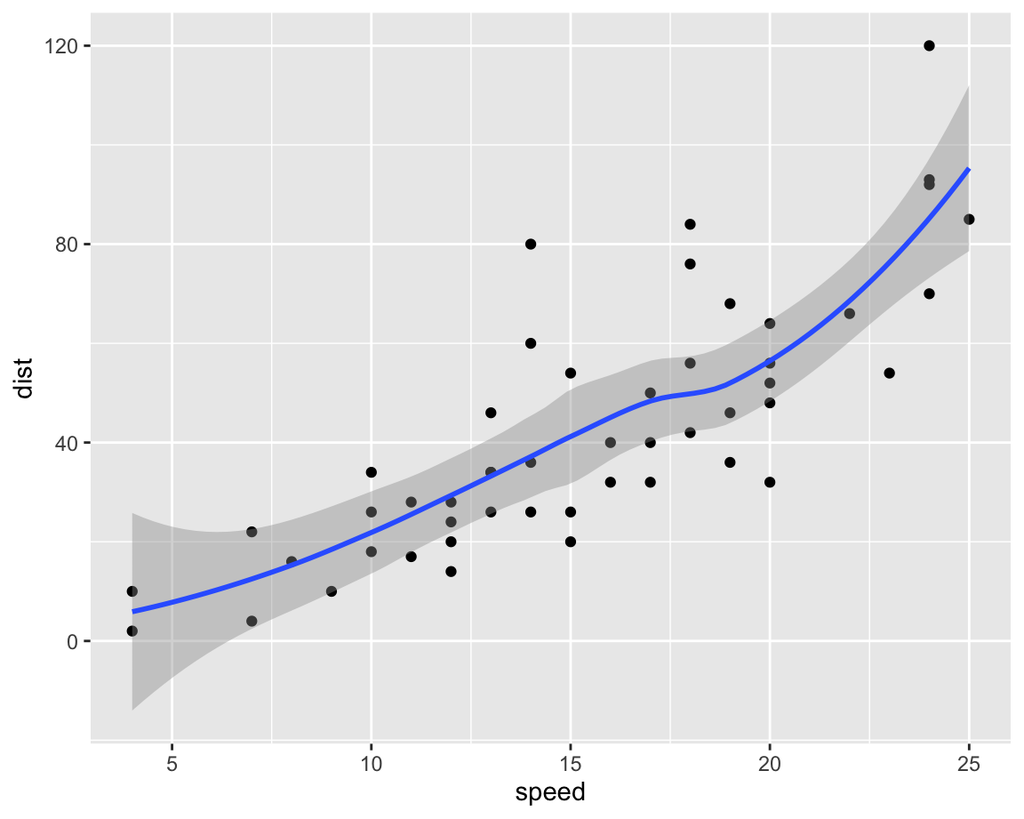

# 5. Installing Software

## Installing Software 1

### Install R

You must install R before anything else.

1. Go to https://www.r-project.org/
2. At the top of the page under Getting Started click on the [download R](http://cran.r-project.org/mirrors.html) link.
3. Select a mirror site to download R. It doesn’t matter which one. A mirror site is an exact duplicate of the main site and is just designed to relive web traffic.
4. If possible, you want to download and install a precompiled binary distribution. Select your OS at the top of the page under **Download and Install R**.
5. If you have a Mac OS X just click on the `.pkg` file to download and install. Other OS require additional steps.
6. Test your install. Open R and type `sessionInfo()`. If you don’t get an error then the install is probably good.

## Installing Software 2

### Install RStudio

You must install R before RStudio.

1. Go to https://rstudio.com/ and hit [Download](https://rstudio.com/products/rstudio/download/).
2. Scroll down and hit the **Download** button under RStudio Desktop Free.
3. Choose you operating system and install RStudio.

## Installing Software 3

### Installing R Packages

I use R instead of RStudio to install all my packages. I have found this prevents any conflicts with installation location. I suggest you do the same.

R packages can be found in several places including GitHub and The Comprehensive R Archive Network, or CRAN. On CRAN alone there are over 15,000 [packages](https://cran.r-project.org/web/packages/available_packages_by_name.html) available. You will need a few packages to get going with you web project and you will likely install several more as the need arises.

I have no idea what comes prepackaged with R. So before you install any packages run the `library(PACKAGE_NAME)` command first. if you do not get an error that means the package is already installed. Here is a list to start with:

- `library(rmarkdown)` if you see `Error in library(rmarkdown) : there is no package called ‘rmarkdown’` then run `install.packages('rmarkdown')`. Depending on your R install, you may have to wrap the package name in single or double quotes when installing. Just play around with it.
- `library(knitr)` or `install.packages('knitr')` if you get an error.
- `library(DT)` or `install.packages('DT')`
- `library(ggplot2)` or `install.packages('ggplot2')`

If you have problems with any of these step, we will try to help. But please know that at least one of us (me) knows nothing about Windows operating systems. We will be in a computationally remote area so please try to take care of any major issues before arriving :)

# 6. Resources

## Resources 1

### Tips & Tricks

#### Getting Help

When you need help the web is your friend. [Stackoverflow](https://stackoverflow.com/) is one of the best resources. If you have a problem, chances are pretty good it has been addressed on Stackoverflow. To learn more about a specific R package you can look at the help pages (each package should have one). In the R terminal or the `Console` window of RStudio type `?packageName` to see the help page. For example, try `?rmarkdown` to see the R markdown help menu.

If you get stuck on a problem or want some advice on how to proceed you can always ask one of the instructors or your classmates. Just make sure you have put in the legwork and have given the problem some thought.

#### Useful Code & other Tidbits

We will use this space to add solutions that we come up with along the way. When you have something to contribute please provide a brief explaination of the problem and solution.

- Render often and run code chunks as you write them. This will make it so much more straightforward to troubleshoot bugs in your code.

## Resources 2

### References & Resources

We will use this space to add use reference and resources that we come up with along the way. When you have something to contribute please provide a brief explaination of the resource.

#### RStudio

- Link to download RStudio. https://rstudio.com/products/rstudio/download/
- Various RStudio cheatsheats. Available for download as pdfs. https://rstudio.com/resources/cheatsheets/
- `knitr` cheatsheet. https://cran.r-project.org/web/packages/knitr/vignettes/knitr-refcard.pdf

#### R Markdown

- R Markdown Quick Tour https://rmarkdown.rstudio.com/authoring_quick_tour.html
- A great intro to R Markdown. https://rmarkdown.rstudio.com/lesson-1.html
- The Definitive R Markdown Guide. https://bookdown.org/yihui/rmarkdown/
- R Markdown formats. HTML is just the tip of the iceberg. https://rmarkdown.rstudio.com/formats.html

#### Next-level web resources

- blogdown: Creating more sophisticated Websites with R Markdown https://bookdown.org/yihui/blogdown/
- Interneting Is Hard. An awesome free course on HTML and CSS for more advanced customization of your site. https://internetingishard.com/html-and-css/

#### General resources

- Freely available HTML, PDF, ePub, and Kindle books about R topics writen in the R Markdown package `bookdown` https://bookdown.org/

# D_Schedule

| Date | Time | Topic | Support Person |
| --- | --- | --- | --- |
| Sun Jan 12 | 8:00 AM- 6:00 PM | Airport pick-ups | Carlos Arias |
|  | 18:00 PM | Dinner at Gamboa schoolhouse |  |
|  |  | Prepare small bag for trip to BCI (4 days/3 nights). Field clothes. |  |
| Mon Jan 13 | Gamboa | Introduction to the Course | Owen McMillan, Carlos Arias, Janeene Touchton |
|  | 7:00 AM | Breakfast |  |
|  | 8:00 AM | Introduction to STRI | Matt Larsen |
|  | 9:00 AM | Intro to Geolgical history of the Isthmus of Panama | Camila Martinez |
|  | 11:00 AM | Intro to BCI | Helene Muller-Landau |
|  | 12:00 PM | Lunch |  |
|  | 2:00 PM | Safety and Security talk | Jose Ramon Perurena |
|  | 3:00-5:00 PM | Introduction to course | Owen McMillan, Carlos Arias, Janeene Touchton |
|  | 6:00 PM | Dinner |  |
|  | 7:30 PM | Project Curation with R-I | Jarrod Scott |
| Tues Jan 14 | Gamboa | Forest Ecology primer | Andy Jones, Owen McMillan, Carlos Arias, Janeene Touchton |
|  | 7:00 AM | Breakfast |  |
|  | 8:00 AM | Short Research Talks | Jannene Touchton, Andy Jones, Erin Spear, Dumas Galves |
|  | 9:00 AM |  |  |
|  | 11:30 AM | Lunch |  |
|  | 12:00 PM | Departure to Gamboa dock to take boat to BCI |  |
|  | 2:00 PM | Settle in BCI |  |
|  | 3:00-5:00 PM | Group hike- 50 hectare plot | Jannene Touchton, Andy Jones, Erin Spear, Dumas Galves |
|  | 6:00 PM | Dinner |  |
|  | 7:30 PM | Meting to discuss projects | Jannene Touchton, Andy Jones, Erin Spear, Owen McMillan, Carlos Arias, Dumas Galves |
| Wed Jan 15 | BCI | Forest Ecology Primer |  |
|  | 6:30 AM | Breakfast |  |
|  | 08:00 AM- 12:00PM | Field Projects | Students |
|  | 12:00 PM -1:00PM | Lunch |  |
|  | 1:00 PM-6:00 PM | Field Projects | Students |
|  | 6:00 PM | Dinner |  |
|  | 7:30 PM | Meting to discuss projects progress | Jannene Touchton, Andy Jones, Erin Spear, Owen McMillan, Carlos Arias, Dumas Galves |

[output cut: 160 more lines]

# Schedule

| Date | Day | Location | Component | Activity | Suporting team |
| --- | --- | --- | --- | --- | --- |
| Thurday Jan 9 | 1 | McGill | Environmental Policy (Check ENVR Syllabus) | Preliminary readings and discussion | Gordon Hickey |
| Friday Jan 10 | 2 | McGill | Environmental Policy (Check ENVR Syllabus) | Preliminary readings and discussion | Gordon Hickey |
| Saturday Jan 11 | 3 | Free day | Reading and Writing day |  |  |
| Sunday Jan 12 | 4 | Gamboa | Accommodation at schoolhouse | Acomodation | Carlos Arias, Janeene Touchton |
| Monday Jan 13 | 5 | Gamboa | Geological and biotic history of Panama | Introduction to the neotropics | Jose Ramon Peruena, Matthew Larsen , Owen McMillan |
| Tuesday Jan 14 | 6 | Gamboa/BCI | Tropical Ecology I | Forest diversity-Students projects I | Andy jones Janeene, Touchton, Erin Spear, Dumas Galves |
| Wednesday Jan 15 | 7 | BCI | Tropical Ecology I | Forest diversity-Students projects I | Andy jones Janeene, Touchton, Erin Spear, Dumas Galves |
| Thursday Jan 16 | 8 | BCI | Tropical Ecology I | Forest diversity-Students projects I | Andy jones Janeene, Touchton, Erin Spear, Dumas Galves |
| Friday Jan 17 | 9 | Free day/return to Gamboa | Reading and Writing day |  |  |
| Saturday Jan 18 | 10 | Gamboa | Tropical Diversity and Adaptation | Insect diversity- Students Project II | Jose Loaiza/ Kelly Bennett/Ummat |
| Sunday Jan 19 | 11 | Gamboa | Tropical Diversity and Adaptation | Insect diversity- Students Project II | Jose Loaiza/ Kelly Bennett/Ummat |
| Monday Jan 20 | 12 | Sherman Crane | Plant Physiology | Plant adaptation | Martjin Slot, Carlos Arias, Janeene Touchton |
| Tuesday Jan 21 | 13 | Gamboa | Tropical Diversity and Adaptation | Heliconius and CRISPR | Chris Kosak/Carolina Concha |
| Wednesday Jan 22 | 14 | Agua Salud | Forest Ecology and Conservation | Agua Salud Project | Jeff Hall/Adriana Tapia/Katherine Sinacore |
| Thursday Jan 23 | 15 | Gamboa | Tropical Diversity and Adaptation | Vertebrate diversity-Students Project III | Michael Logan /Carlos Arias/Janeene |
| Friday Jan 24 | 16 | Gamboa | Tropical Diversity and Adaptation | Vertebrate diversity-Students Project III | Michael Logan /Carlos Arias/Janeene |
| Saturday Jan 25 | 17 | Gamboa | Tropical Diversity and Adaptation | Vertebrate diversity-Students Project III | Michael Logan /Carlos Arias/Janeene |
| Sunday Jan 26 | 18 | Fee day | Reading and Writing day |  |  |
| Monday Jan 27 | 19 | Travel to Coiba |  |  |  |
| Tuesday Jan 28 | 20 | Coiba | Marine Ecology and Conservation | Marine diversity- Student project V | Matt Leray/Davey Klein |
| Wednesday Jan 29 | 21 | Coiba | Marine Ecology and Conservation | Marine diversity- Student project V | Matt Leray/Davey Klein |
| Thursday Jan 30 | 22 | Coiba | Marine Ecology and Conservation | Marine diversity- Student project V | Matt Leray/Davey Klein |
| Friday Jan 31 | 23 | Travel back |  |  |  |
| Saturday Feb 1 | 24 | Free day | Reading and Writing day |  |  |
| Sunday Feb 2 | 25 | Free day | Reading and Writing day |  |  |
| Monday Feb 3 | 26 | Gamboa | Environmental Policy | Discussion | Gordon Hickey |
| Tuesday Feb 4 | 27 | Gamboa | Environmental Policy | Discussion | Gordon Hickey |
| wednesday Feb 5 | 28 | Gamboa | Environmental Policy | Discussion | Gordon Hickey |
| Thurday Feb 6 | 29 | Gamboa | Environmental Policy | Discussion | Gordon Hickey |
| Friday Feb 7 | 30 | Gamboa/course ends | Environmental Policy | Discussion | Gordon Hickey |